# BIOS 611 Project 3

## Summary statistics based on ethnicity

```r
non_his_lat = subset(dat, dat$`Client Ethnicity` == "Non-Hispanic/Non-Latino (HUD)")

his_lat = subset(dat, dat$`Client Ethnicity` == "Hispanic/Latino (HUD)")

no_data = subset(dat, dat$`Client Ethnicity` == "Data not collected (HUD)")

refused = subset(dat, dat$`Client Ethnicity` == "Client refused (HUD)")

unknown = subset(dat, dat$`Client Ethnicity` == "Client doesn't know (HUD)")

summary(non_his_lat)
```

```
##  EE Provider ID_x      EE UID_x       Client Unique ID_x   Client ID
##  Length:24283       Min.   : 566663   Length:24283       Min.   :   1096
##  Class :character   1st Qu.: 700816   Class :character   1st Qu.: 200794
##  Mode  :character   Median : 772263   Mode  :character   Median : 333631
##                     Mean   : 797464                      Mean   : 308495
##                     3rd Qu.: 880804                      3rd Qu.: 400414
##                     Max.   :1074506                      Max.   :1004266
##
##  Client Age at Entry Client Age at Exit Client Gender
##  Min.   :18.00       Min.   :18.00      Length:24283
##  1st Qu.:38.00       1st Qu.:38.00      Class :character
##  Median :47.00       Median :47.00      Mode  :character
##  Mean   :44.91       Mean   :44.99
##  3rd Qu.:53.00       3rd Qu.:54.00
##  Max.   :81.00       Max.   :81.00
##
##  Client Primary Race Client Ethnicity   Client Veteran Status
##  Length:24283        Length:24283       Length:24283
##  Class :character    Class :character   Class :character
##  Mode  :character    Mode  :character   Mode  :character
##
##
##
##
##  EE Provider ID_y      EE UID_y       Client Unique ID_y
##  Length:24283       Min.   : 566663   Length:24283
##  Class :character   1st Qu.: 700816   Class :character
##  Mode  :character   Median : 772263   Mode  :character
##                     Mean   : 797464
##                     3rd Qu.: 880804
##                     Max.   :1074506
##
##  Entry Exit Group Id Entry Exit Household Id  Unnamed: 6
##  Length:24283        Length:24283            Length:24283
##  Class :character    Class :character        Class :character
##  Mode  :character    Mode  :character        Mode  :character
##
##
##
##
```

[output cut: 25 more lines]

```
##  Min.   :    0          Min.   : 0.000
##  1st Qu.:    0          1st Qu.: 0.000
##  Median : 1200          Median : 0.000
##  Mean   : 5645          Mean   : 2.462
##  3rd Qu.: 6678          3rd Qu.: 3.000
##  Max.   :34628          Max.   :25.000
##
##  Number of Disabilities at Entry
##  Min.   :0
##  1st Qu.:0
##  Median :0
##  Mean   :0
##  3rd Qu.:0
##  Max.   :0
##
```

```r
summary(his_lat)
```

```
##  EE Provider ID_x      EE UID_x       Client Unique ID_x   Client ID
##  Length:1160        Min.   : 601258   Length:1160        Min.   : 140619
##  Class :character   1st Qu.: 738093   Class :character   1st Qu.: 204770
##  Mode  :character   Median : 792142   Mode  :character   Median : 287048
##                     Mean   : 820094                      Mean   : 292927
##                     3rd Qu.: 887753                      3rd Qu.: 346065
##                     Max.   :1073370                      Max.   :1003772
##
##  Client Age at Entry Client Age at Exit Client Gender
##  Min.   :18.00       Min.   :18.0       Length:1160
##  1st Qu.:39.00       1st Qu.:39.0       Class :character
##  Median :50.00       Median :50.0       Mode  :character
##  Mean   :46.16       Mean   :46.2
##  3rd Qu.:52.00       3rd Qu.:52.0
##  Max.   :68.00       Max.   :68.0
##
##  Client Primary Race Client Ethnicity   Client Veteran Status
##  Length:1160         Length:1160        Length:1160
##  Class :character    Class :character   Class :character
##  Mode  :character    Mode  :character   Mode  :character
##
##
##
##
##  EE Provider ID_y      EE UID_y       Client Unique ID_y
##  Length:1160        Min.   : 601258   Length:1160
##  Class :character   1st Qu.: 738093   Class :character
##  Mode  :character   Median : 792142   Mode  :character
##                     Mean   : 820094
##                     3rd Qu.: 887753
##                     Max.   :1073370
##
##  Entry Exit Group Id Entry Exit Household Id  Unnamed: 6
##  Length:1160         Length:1160             Length:1160
##  Class :character    Class :character        Class :character
##  Mode  :character    Mode  :character        Mode  :character
##
##
##
##
```

[output cut: 25 more lines]

```
##  Min.   :   0           Min.   :0.0000
##  1st Qu.:   0           1st Qu.:0.0000
##  Median :   0           Median :0.0000
##  Mean   :2734           Mean   :0.1879
##  3rd Qu.:5900           3rd Qu.:0.0000
##  Max.   :9360           Max.   :5.0000
##
##  Number of Disabilities at Entry
##  Min.   :0
##  1st Qu.:0
##  Median :0
##  Mean   :0
##  3rd Qu.:0
##  Max.   :0
##
```

```r
summary(no_data)
```

```
##  EE Provider ID_x      EE UID_x       Client Unique ID_x   Client ID
##  Length:18          Min.   : 632127   Length:18          Min.   :315493
##  Class :character   1st Qu.: 664918   Class :character   1st Qu.:394311
##  Mode  :character   Median : 672970   Mode  :character   Median :400077
##                     Mean   : 691517                      Mean   :393985
##                     3rd Qu.: 688372                      3rd Qu.:400077
##                     Max.   :1057783                      Max.   :401497
##  Client Age at Entry Client Age at Exit Client Gender
##  Min.   :22.00       Min.   :22.00      Length:18
##  1st Qu.:29.00       1st Qu.:29.00      Class :character
##  Median :41.00       Median :42.00      Mode  :character
##  Mean   :38.39       Mean   :38.56
##  3rd Qu.:42.00       3rd Qu.:42.00
##  Max.   :52.00       Max.   :52.00
##  Client Primary Race Client Ethnicity   Client Veteran Status
##  Length:18           Length:18          Length:18
##  Class :character    Class :character   Class :character
##  Mode  :character    Mode  :character   Mode  :character
##
##
##
##  EE Provider ID_y      EE UID_y       Client Unique ID_y
##  Length:18          Min.   : 632127   Length:18
##  Class :character   1st Qu.: 664918   Class :character
##  Mode  :character   Median : 672970   Mode  :character
##                     Mean   : 691517
##                     3rd Qu.: 688372
##                     Max.   :1057783
##  Entry Exit Group Id Entry Exit Household Id  Unnamed: 6
##  Length:18           Length:18               Length:18
##  Class :character    Class :character        Class :character
##  Mode  :character    Mode  :character        Mode  :character
##
##
##
##    Entry Date         Housing Move-in Date(5584)   Exit Date
##  Min.   :2015-02-05   Length:18                  Min.   :2015-02-07
##  1st Qu.:2015-05-18   Class :character           1st Qu.:2015-06-14
##  Median :2015-06-19   Mode  :character           Median :2015-07-25
##  Mean   :2015-08-27                              Mean   :2015-09-16
```

[output cut: 15 more lines]

```
##
##  Monthly Amount (Entry) Number of Noncash at Entry
##  Min.   :   0.0         Min.   :0.0000
##  1st Qu.:   0.0         1st Qu.:0.0000
##  Median :   0.0         Median :0.0000
##  Mean   : 605.8         Mean   :0.8889
##  3rd Qu.:1260.0         3rd Qu.:2.0000
##  Max.   :1466.0         Max.   :2.0000
##  Number of Disabilities at Entry
##  Min.   :0
##  1st Qu.:0
##  Median :0
##  Mean   :0
##  3rd Qu.:0
##  Max.   :0
```

```r
summary(refused)
```

```
##  EE Provider ID_x      EE UID_x      Client Unique ID_x   Client ID
##  Length:7           Min.   :666517   Length:7           Min.   :  3953
##  Class :character   1st Qu.:742422   Class :character   1st Qu.:305617
##  Mode  :character   Median :793907   Mode  :character   Median :433563
##                     Mean   :784821                      Mean   :339794
##                     3rd Qu.:810814                      3rd Qu.:433563
##                     Max.   :926851                      Max.   :462685
##  Client Age at Entry Client Age at Exit Client Gender
##  Min.   :25.00       Min.   :26.0       Length:7
##  1st Qu.:25.50       1st Qu.:26.0       Class :character
##  Median :26.00       Median :26.0       Mode  :character
##  Mean   :40.71       Mean   :41.0
##  3rd Qu.:59.50       3rd Qu.:59.5
##  Max.   :64.00       Max.   :64.0
##  Client Primary Race Client Ethnicity   Client Veteran Status
##  Length:7            Length:7           Length:7
##  Class :character    Class :character   Class :character
##  Mode  :character    Mode  :character   Mode  :character
##
##
##
##  EE Provider ID_y      EE UID_y      Client Unique ID_y
##  Length:7           Min.   :666517   Length:7
##  Class :character   1st Qu.:742422   Class :character
##  Mode  :character   Median :793907   Mode  :character
##                     Mean   :784821
##                     3rd Qu.:810814
##                     Max.   :926851
##  Entry Exit Group Id Entry Exit Household Id  Unnamed: 6
##  Length:7            Length:7                Length:7
##  Class :character    Class :character        Class :character
##  Mode  :character    Mode  :character        Mode  :character
##
##
##
##    Entry Date         Housing Move-in Date(5584)   Exit Date
##  Min.   :2015-05-23   Length:7                   Min.   :2015-06-02
##  1st Qu.:2016-02-08   Class :character           1st Qu.:2016-02-29
##  Median :2016-07-25   Mode  :character           Median :2016-08-29
##  Mean   :2016-06-28                              Mean   :2016-07-20
```

[output cut: 15 more lines]

```
##
##  Monthly Amount (Entry) Number of Noncash at Entry
##  Min.   :  0.0          Min.   :0.000
##  1st Qu.:270.0          1st Qu.:0.500
##  Median :270.0          Median :2.000
##  Mean   :354.3          Mean   :1.286
##  3rd Qu.:435.0          3rd Qu.:2.000
##  Max.   :800.0          Max.   :2.000
##  Number of Disabilities at Entry
##  Min.   :0
##  1st Qu.:0
##  Median :0
##  Mean   :0
##  3rd Qu.:0
##  Max.   :0
```

```r
summary(unknown)
```

```
##  EE Provider ID_x      EE UID_x       Client Unique ID_x   Client ID
##  Length:5           Min.   : 816563   Length:5           Min.   : 151291
##  Class :character   1st Qu.: 818204   Class :character   1st Qu.: 267503
##  Mode  :character   Median :1022186   Mode  :character   Median : 268176
##                     Mean   : 951489                      Mean   : 409622
##                     3rd Qu.:1027597                      3rd Qu.: 357481
##                     Max.   :1072893                      Max.   :1003658
##
##  Client Age at Entry Client Age at Exit Client Gender
##  Min.   :27.0        Min.   :27         Length:5
##  1st Qu.:31.0        1st Qu.:31         Class :character
##  Median :42.0        Median :42         Mode  :character
##  Mean   :45.8        Mean   :46
##  3rd Qu.:64.0        3rd Qu.:65
##  Max.   :65.0        Max.   :65
##
##  Client Primary Race Client Ethnicity   Client Veteran Status
##  Length:5            Length:5           Length:5
##  Class :character    Class :character   Class :character
##  Mode  :character    Mode  :character   Mode  :character
##
##
##
##
##  EE Provider ID_y      EE UID_y       Client Unique ID_y
##  Length:5           Min.   : 816563   Length:5
##  Class :character   1st Qu.: 818204   Class :character
##  Mode  :character   Median :1022186   Mode  :character
##                     Mean   : 951489
##                     3rd Qu.:1027597
##                     Max.   :1072893
##
##  Entry Exit Group Id Entry Exit Household Id  Unnamed: 6
##  Length:5            Length:5                Length:5
##  Class :character    Class :character        Class :character
##  Mode  :character    Mode  :character        Mode  :character
##
##
##
##
```

[output cut: 25 more lines]

```
##  Min.   :   0.0         Min.   :0.0
##  1st Qu.:   0.0         1st Qu.:1.0
##  Median :   0.0         Median :1.0
##  Mean   : 361.6         Mean   :0.8
##  3rd Qu.: 753.0         3rd Qu.:1.0
##  Max.   :1055.0         Max.   :1.0
##
##  Number of Disabilities at Entry
##  Min.   :0
##  1st Qu.:0
##  Median :0
##  Mean   :0
##  3rd Qu.:0
##  Max.   :0
##
```

## Summary statistics based on veteran status

```r
y_vet =  subset(dat, dat$`Client Veteran Status` == "Yes (HUD)")
n_vet =  subset(dat, dat$`Client Veteran Status` == "No (HUD)")
na_vet = subset(dat, dat$`Client Veteran Status` == "Data not collected (HUD)")

summary(y_vet)
```

```
##  EE Provider ID_x      EE UID_x       Client Unique ID_x   Client ID
##  Length:2095        Min.   : 594343   Length:2095        Min.   :   1096
##  Class :character   1st Qu.: 707688   Class :character   1st Qu.: 185048
##  Mode  :character   Median : 769773   Mode  :character   Median : 360237
##                     Mean   : 797168                      Mean   : 303898
##                     3rd Qu.: 879754                      3rd Qu.: 373730
##                     Max.   :1073907                      Max.   :1002542
##
##  Client Age at Entry Client Age at Exit Client Gender
##  Min.   :19.00       Min.   :19.00      Length:2095
##  1st Qu.:49.00       1st Qu.:49.00      Class :character
##  Median :53.00       Median :54.00      Mode  :character
##  Mean   :53.44       Mean   :53.53
##  3rd Qu.:60.00       3rd Qu.:60.00
##  Max.   :77.00       Max.   :77.00
##
##  Client Primary Race Client Ethnicity   Client Veteran Status
##  Length:2095         Length:2095        Length:2095
##  Class :character    Class :character   Class :character
##  Mode  :character    Mode  :character   Mode  :character
##
##
##
##
##  EE Provider ID_y      EE UID_y       Client Unique ID_y
##  Length:2095        Min.   : 594343   Length:2095
##  Class :character   1st Qu.: 707688   Class :character
##  Mode  :character   Median : 769773   Mode  :character
##                     Mean   : 797168
##                     3rd Qu.: 879754
##                     Max.   :1073907
##
##  Entry Exit Group Id Entry Exit Household Id  Unnamed: 6
##  Length:2095         Length:2095             Length:2095
##  Class :character    Class :character        Class :character
##  Mode  :character    Mode  :character        Mode  :character
##
##
##
##
```

[output cut: 25 more lines]

```
##  Min.   :    0          Min.   : 0.000
##  1st Qu.: 1015          1st Qu.: 0.000
##  Median : 3700          Median : 0.000
##  Mean   : 5591          Mean   : 3.564
##  3rd Qu.: 7931          3rd Qu.: 3.000
##  Max.   :16866          Max.   :17.000
##
##  Number of Disabilities at Entry
##  Min.   :0
##  1st Qu.:0
##  Median :0
##  Mean   :0
##  3rd Qu.:0
##  Max.   :0
##
```

```r
summary(n_vet)
```

```
##  EE Provider ID_x      EE UID_x       Client Unique ID_x   Client ID
##  Length:23366       Min.   : 566663   Length:23366       Min.   :   1097
##  Class :character   1st Qu.: 701478   Class :character   1st Qu.: 202759
##  Mode  :character   Median : 773688   Mode  :character   Median : 331381
##                     Mean   : 798458                      Mean   : 308042
##                     3rd Qu.: 880804                      3rd Qu.: 400414
##                     Max.   :1074506                      Max.   :1004212
##
##  Client Age at Entry Client Age at Exit Client Gender
##  Min.   :18.0        Min.   :18.00      Length:23366
##  1st Qu.:37.0        1st Qu.:37.00      Class :character
##  Median :46.0        Median :46.00      Mode  :character
##  Mean   :44.2        Mean   :44.28
##  3rd Qu.:52.0        3rd Qu.:52.00
##  Max.   :81.0        Max.   :81.00
##
##  Client Primary Race Client Ethnicity   Client Veteran Status
##  Length:23366        Length:23366       Length:23366
##  Class :character    Class :character   Class :character
##  Mode  :character    Mode  :character   Mode  :character
##
##
##
##
##  EE Provider ID_y      EE UID_y       Client Unique ID_y
##  Length:23366       Min.   : 566663   Length:23366
##  Class :character   1st Qu.: 701478   Class :character
##  Mode  :character   Median : 773688   Mode  :character
##                     Mean   : 798458
##                     3rd Qu.: 880804
##                     Max.   :1074506
##
##  Entry Exit Group Id Entry Exit Household Id  Unnamed: 6
##  Length:23366        Length:23366            Length:23366
##  Class :character    Class :character        Class :character
##  Mode  :character    Mode  :character        Mode  :character
##
##
##
##
```

[output cut: 25 more lines]

```
##  Min.   :    0          Min.   : 0.00
##  1st Qu.:    0          1st Qu.: 0.00
##  Median :  800          Median : 0.00
##  Mean   : 5502          Mean   : 2.25
##  3rd Qu.: 6300          3rd Qu.: 3.00
##  Max.   :34628          Max.   :25.00
##
##  Number of Disabilities at Entry
##  Min.   :0
##  1st Qu.:0
##  Median :0
##  Mean   :0
##  3rd Qu.:0
##  Max.   :0
##
```

```r
summary(na_vet)
```

```
##  EE Provider ID_x      EE UID_x      Client Unique ID_x   Client ID
##  Length:2           Min.   :710273   Length:2           Min.   :415901
##  Class :character   1st Qu.:765098   Class :character   1st Qu.:429115
##  Mode  :character   Median :819924   Mode  :character   Median :442328
##                     Mean   :819924                      Mean   :442328
##                     3rd Qu.:874750                      3rd Qu.:455542
##                     Max.   :929575                      Max.   :468756
##  Client Age at Entry Client Age at Exit Client Gender
##  Min.   :39.00       Min.   :39.00      Length:2
##  1st Qu.:47.25       1st Qu.:47.25      Class :character
##  Median :55.50       Median :55.50      Mode  :character
##  Mean   :55.50       Mean   :55.50
##  3rd Qu.:63.75       3rd Qu.:63.75
##  Max.   :72.00       Max.   :72.00
##  Client Primary Race Client Ethnicity   Client Veteran Status
##  Length:2            Length:2           Length:2
##  Class :character    Class :character   Class :character
##  Mode  :character    Mode  :character   Mode  :character
##
##
##
##  EE Provider ID_y      EE UID_y      Client Unique ID_y
##  Length:2           Min.   :710273   Length:2
##  Class :character   1st Qu.:765098   Class :character
##  Mode  :character   Median :819924   Mode  :character
##                     Mean   :819924
##                     3rd Qu.:874750
##                     Max.   :929575
##  Entry Exit Group Id Entry Exit Household Id  Unnamed: 6
##  Length:2            Length:2                Length:2
##  Class :character    Class :character        Class :character
##  Mode  :character    Mode  :character        Mode  :character
##
##
##
##    Entry Date         Housing Move-in Date(5584)   Exit Date
##  Min.   :2015-11-09   Length:2                   Min.   :2015-11-11
##  1st Qu.:2016-05-11   Class :character           1st Qu.:2016-05-21
##  Median :2016-11-12   Mode  :character           Median :2016-11-29
##  Mean   :2016-11-12                              Mean   :2016-11-29
```

[output cut: 15 more lines]

```
##
##  Monthly Amount (Entry) Number of Noncash at Entry
##  Min.   :   0           Min.   :0.00
##  1st Qu.: 338           1st Qu.:0.25
##  Median : 676           Median :0.50
##  Mean   : 676           Mean   :0.50
##  3rd Qu.:1014           3rd Qu.:0.75
##  Max.   :1352           Max.   :1.00
##  Number of Disabilities at Entry
##  Min.   :0
##  1st Qu.:0
##  Median :0
##  Mean   :0
##  3rd Qu.:0
##  Max.   :0
```

## Destinations of clients after leaving the shelter

```r
unique(dat$Destination)
```

```
##  [1] "Rental by client, with other ongoing housing subsidy (HUD)"
##  [2] "Staying or living with family, temporary tenure (HUD)"
##  [3] "Other (HUD)"
##  [4] "Data not collected (HUD)"
##  [5] "Staying or living with friends, temporary tenure (HUD)"
##  [6] "Hospital or other residential non-psychiatric medical facility (HUD)"
##  [7] "Staying or living with friends, permanent tenure (HUD)"
##  [8] NA
##  [9] "Client doesn't know (HUD)"
## [10] "Rental by client, no ongoing housing subsidy (HUD)"
## [11] "Transitional housing for homeless persons (including homeless youth) (HUD)"
## [12] "Rental by client, with VASH housing subsidy (HUD)"
## [13] "Rental by client, with RRH or equivalent subsidy (HUD)"
## [14] "Jail, prison or juvenile detention facility (HUD)"
## [15] "No exit interview completed (HUD)"
## [16] "Place not meant for habitation (HUD)"
## [17] "Staying or living with family, permanent tenure (HUD)"
## [18] "Permanent housing (other than RRH) for formerly homeless persons (HUD)"
## [19] "Emergency shelter, incl. hotel/motel paid for w/ ES voucher, or RHY-funded Host Home shelter (HUD)"
## [20] "Psychiatric hospital or other psychiatric facility (HUD)"
## [21] "Safe Haven (HUD)"
## [22] "Substance abuse treatment facility or detox center (HUD)"
## [23] "Hotel or motel paid for without emergency shelter voucher (HUD)"
## [24] "Long-term care facility or nursing home (HUD)"
## [25] "Client refused (HUD)"
## [26] "Residential project or halfway house with no homeless criteria (HUD)"
## [27] "Owned by client, with ongoing housing subsidy (HUD)"
## [28] "Owned by client, no ongoing housing subsidy (HUD)"
## [29] "Deceased (HUD)"
## [30] "Rental by client in a public housing unit (HUD)"
```

## Reasons for leaving the shelter

```r
unique(dat$`Reason for Leaving`)
```

```
##  [1] "Completed program"
##  [2] "Other"
##  [3] "Needs could not be met"
##  [4] NA
##  [5] "Does not or no longer qualifies for program"
##  [6] "Reached maximum time allowed"
##  [7] "Unknown/Disappeared"
##  [8] "Criminal activity / violence"
##  [9] "Non-compliance with program"
## [10] "Left for housing opp. before completing program"
## [11] "Disagreement with rules/persons"
## [12] "z-Emergency Shelter (SAHP)"
## [13] "Non-payment of rent"
## [14] "z - AHOPE - client found housing on own"
## [15] "Death"
## [16] "z-Left before completing program (not a HUD answer)"
```

## Explore how the length of stay relates to client demographics

```r
# Extract number of days from the character type variable `Days Stayed` and cast it into int
library(stringr)
numextract <- function(string){
  str_extract(string, "\\-*\\d+\\.*\\d*")
}

days_stayed = numextract(dat$`Days Stayed`)
days_stayed = as.numeric(days_stayed)
dat$`Days Stayed` = days_stayed
```

### Explore the pattern of the length of stay with respect client’s age and gender.

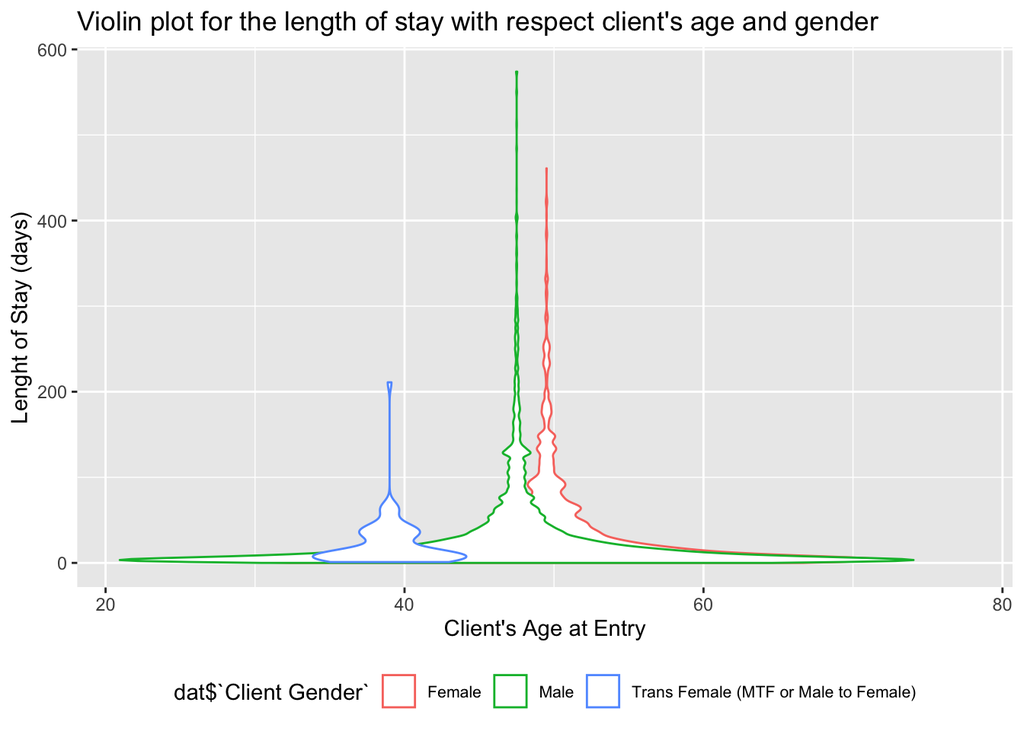

```r
ggplot(dat, mapping = aes(x = dat$`Client Age at Entry`, y = dat$`Days Stayed`,
                        group = dat$`Client Gender`, color = dat$`Client Gender`, legend = dat$`Client Gender`)) +
  geom_violin() +
  theme(legend.text = element_text(size = 8), legend.position = 'bottom') +
  labs(title = "Violin plot for the length of stay with respect client's age and gender") +
  xlab("Client's Age at Entry") +
  ylab("Lenght of Stay (days)")
```

```r
ggsave('/Users/September/Documents/GitHub/bios611-projects-fall-2019-September-C/project_3/results/age_gender.png', height=4, width=7)
```

#### Observations

- For male clients, the length of stay is the longest for those around 45 to 50 years old.
- For female clients, the length of stay is the longest for those around 45 to 55 years old.
- For trans female clients, the length of stay is the longest for those around 35 to 45 years old.

### Explore the pattern of the length of stay with respect client’s income at entry.

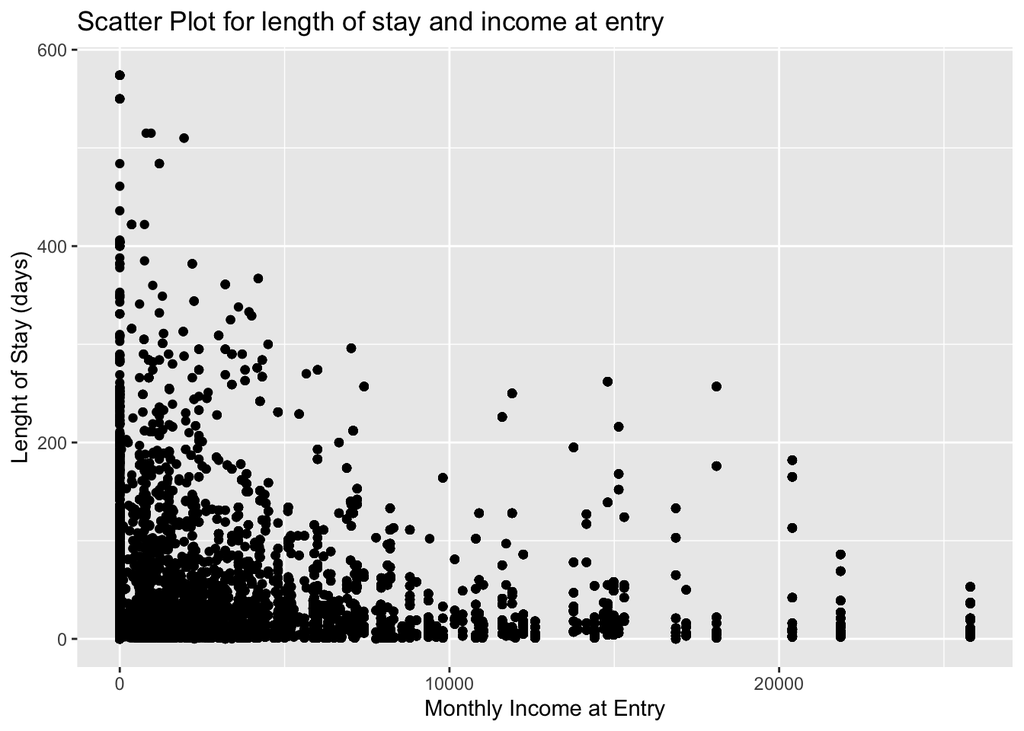

```r
ggplot(dat %>% filter(`Monthly Amount (Entry)` < 30000),
       mapping = aes(x = `Monthly Amount (Entry)`, y = `Days Stayed`)) +
  geom_point() +
  labs(title = "Scatter Plot for length of stay and income at entry")+
  xlab("Monthly Income at Entry")+
  ylab("Lenght of Stay (days)")
```

```r
ggsave('/Users/September/Documents/GitHub/bios611-projects-fall-2019-September-C/project_3/results/stay_income.png', height=4, width=7)
```

#### Observations

We observe a negative association between client’s monthly income at time of entry and their length of staying at the shelter.

### Explore the pattern of the length of stay with respect client’s number of noncash services at entry.

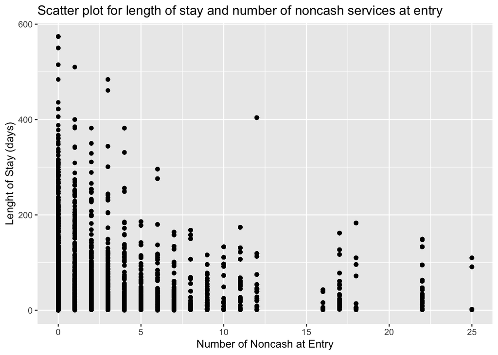

```r
ggplot(dat,mapping = aes(x = `Number of Noncash at Entry`, y = `Days Stayed`)) +
  geom_point() +
  labs(title = "Scatter plot for length of stay and number of noncash services at entry")+
  xlab("Number of Noncash at Entry")+
  ylab("Lenght of Stay (days)")
```

```r
ggsave('/Users/September/Documents/GitHub/bios611-projects-fall-2019-September-C/project_3/results/stay_noncash.png', height=4, width=7)
```

#### Observations

We observe a negative association between client’s number of noncash services at time of entry and their length of staying at the shelter.